# Итерация и рекурсия (2)

Данное занятие продолжает рассмотрении рекурсии

Рассмотрим задачу нахождения n-ого члена ряда Фибоначчи

0,1,1,2,3,5,8,13,21,34,55...

В этом ряду определяются элементы с номерами 1 и 2, а последующие элементы считаются как сумма двух предыдущих элементов

```python
#include <iostream>
#include <ctime>
typedef unsigned long long ull;
```

С помощью конструкции **typedef** определяем псевдоним для 8-байтного беззнакового целого (чтобы писать более короткие выражения)

```python
// 0,1,1,2,3,5,8,13,21,34,55...

ull fib(ull n)
{
    if(n==1)
        return 0;
    if(n==2)
        return 1;
    else
        return fib(n-1) + fib(n-2);
}
```

После измерений построим график зависимости времени работы от n.

```python
for(int i = 0, n = 30; i < 7; i++, n+=2) {
   clock_t start = clock();
   ull result = fib(n);
   clock_t finish = clock();
   std::cout << (double)(finish-start)/CLOCKS_PER_SEC << std::endl;
}
```

```
0.003624
0.010466
0.025308
0.062046
0.161961
0.419963
1.10293
```

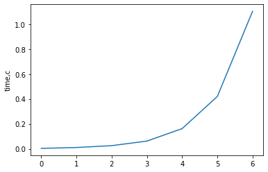

```python
import matplotlib.pyplot as plt

arr = [0.003624,
0.010466,
0.025308,
0.062046,
0.161961,
0.419963,
1.10293]

plt.plot(arr)
plt.ylabel('time,c')
plt.show()
```

Нетрудно видеть, что время растет по экспоненциальному закону. Это вызвано тем, что при вычислениях мы не где не сохраняем ранее вычислнные значения и их приходится считать по 2 раза (для n-1 и для n-2). В результате разрастается дерево рекурсии.

[figure not shown]

Теперь изменим решение, перейдя от экспоненциальной рекурсии к линейной. Для этого, накопленная сумма двух элементов передается при рекурсивном вызове. Мы также передаем счетчик, который считает от n до 0 и 0 выступает условием выхода из рекурсии.

```python
// 0,1,1,2,3,5,8,13,21,34,...
ull fibIter(ull a, ull b, ull count) {
    if(count==0)
        return b;
    else
        return fibIter(a + b, a, --count);
}
// decorate
ull fib2(ull n) {
    return fibIter(0,1,n);
}
```

n=1 a=0 b=1 count=1 a=1 b=0 count=0 -> 0

n=2 a=0 b=1 count=2 a=1 b=0 count=1 a=1 b=1 count=0. -> 1

n=3 a=0 b=1 count=3 a=1 b=0 count=2 a=1 b=1 count=1 a=2 b=1 count=0 -> 1

*Домашнее задание 1*. Итеративная реализация вычисления ряда Фибоначчи

Написать функцию вычисления элемента ряда Фибоначчи, основанную на цикле.

*Домашнее задание 2*. Написать рекурсивную функцию вычисления "шахматного числа"

"Шахматное число" равно сумме всех зерен, размещенных на шахматной доске по принципу ряда: $1,2,4,8,....,2^{63}$

*Домашнее задание 3*.

Выполнить задание в тренировочном репозитории https://github.com/NNTU-CS/ADS-0.git